# Data for *usensys* models

@olugovoy

May 4, 2019

# Obtaining EIA data

## By states

Downloading data from https://www.eia.gov/electricity/data/state/.

Version:  
Final annual data for 2017  
Release Date: October 12, 2018  
Next Release Date: November 2019  
Re-released: January 15, 2019 Revision/Corrections https://www.eia.gov/electricity/data/state/correction.php

```r
eiadir <- file.path(getwd(), "data/EIA")
if(!dir.exists(eiadir)) dir.create(eiadir, recursive = T)

{www <- list()
# Annual data ####
# 1990 - 2017   Net Generation by State by Type of Producer by Energy Source (EIA-906, EIA-920, and EIA-923)
www$annual_generation_state.xls <- "https://www.eia.gov/electricity/data/state/annual_generation_state.xls"
# 1990 - 2017   Fossil Fuel Consumption for Electricity Generation by Year, Industry Type and State (EIA-906, EIA-920, and EIA-923)2
www$annual_consumption_state.xls <- "https://www.eia.gov/electricity/data/state/annual_consumption_state.xls"
# 1990 - 2017   Existing Nameplate and Net Summer Capacity by Energy Source, Producer Type and State (EIA-860)1, 3
www$existcapacity_annual.xlsx <- "https://www.eia.gov/electricity/data/state/existcapacity_annual.xlsx"
# 2018 - 2022   Proposed Nameplate and Net Summer Capacity by Year, Energy Source, and State (EIA-860)1
www$plancapacity_annual.xlsx <- "https://www.eia.gov/electricity/data/state/plancapacity_annual.xlsx"
# 1990 - 2017   U.S. Electric Power Industry Estimated Emissions by State (EIA-767, EIA-906, EIA-920, and EIA-923)4
www$emission_annual.xls <- "https://www.eia.gov/electricity/data/state/emission_annual.xls"
# 1990 - 2017   Average Price by State by Provider (EIA-861)5
www$avgprice_annual.xlsx <- "https://www.eia.gov/electricity/data/state/avgprice_annual.xlsx"
# 1990 - 2017   Number of Retail Customers by State by Sector (EIA-861)5
www$customers_annual.xlsx <- "https://www.eia.gov/electricity/data/state/customers_annual.xlsx"
# 1990 - 2017   Retail Sales of Electricity by State by Sector by Provider (EIA-861)5
www$sales_annual.xlsx <- "https://www.eia.gov/electricity/data/state/sales_annual.xlsx"
# 1990 - 2017   Revenue from Retail Sales of Electricity by State by Sector by Provider (EIA-861)5
www$revenue_annual.xlsx <- "https://www.eia.gov/electricity/data/state/revenue_annual.xlsx"
# 2001 - 2003   Financial Data on Publicly Owned Electric Utilities with Generation Facilities by State (EIA-412)6
www$financewgen_annual.xls <- "https://www.eia.gov/electricity/data/state/financewgen_annual.xls"
# 2001 - 2003   Financial Data on Publicly Owned Electric Utilities without Generation Facilities by State (EIA-412)6
www$financewogen_annual.xls <- "https://www.eia.gov/electricity/data/state/financewogen_annual.xls"

# Monthly data from Electric Power Monthly ####
# 2001 - Present    Net Generation by State by Type of Producer by Energy Source1
www$generation_monthly.xlsx <- "https://www.eia.gov/electricity/data/state/generation_monthly.xlsx"
# 2001 - Present    Fossil Fuel Consumption for Electricity Generation by Year, Industry Type and State2
www$consumption_monthly.xlsx <- "https://www.eia.gov/electricity/data/state/consumption_monthly.xlsx"}

download <- function(url, path = eiadir, overwrite = FALSE) {
  fl <- file.path(path, basename(url))
  if(file.exists(fl) & !overwrite) {
    # message("File '", basename(url), "' already exists.")
    return("exists")
  } else {
    download.file(url = url, destfile = fl, mode = "wb")
    if(file.exists(fl)) {
      return("downloaded")
    } else {
      return("download failed")
    }
  }
}

sapply(www, download, overwrite = F)

# Annual capacity
elc_cap <- read_excel(file.path(eiadir, basename(www$existcapacity_annual.xlsx)),
                      sheet = "Existing Capacity",
                      range = "A1:H42756")
elc_cap

# Fuels consumption for electricity generation by months
fue4elc <- read_excel(file.path(eiadir, basename(www$consumption_monthly.xlsx)),
                      sheet = "2017_Preliminary",
                      range = "A5:F9391")
fue4elc

# Electricity generation by months and energy type
elc_gen <- read_excel(file.path(eiadir, basename(www$generation_monthly.xlsx)),
                      sheet = "2017_Preliminary",
                      range = "A5:F24880")
elc_gen

elc_emis <- read_excel(file.path(eiadir, basename(www$emission_annual.xls)),
                      sheet = "State Emissions",
                      range = "A1:G24880")
elc_emis

save(elc_cap, fue4elc, elc_gen, elc_emis, file = file.path(eiadir, "eia_raw.RData"))
```

## Power plants & generator level data

### Form EIA-860 detailed data with previous form data (EIA-860A/860B

https://www.eia.gov/electricity/data/eia860/  
Release Date: September 13, 2018, Final 2017 data  
Next release date: June 2019, Early release 2018 data  
The survey Form EIA-860 collects generator-level specific information about existing and planned generators and associated environmental equipment at electric power plants with 1 megawatt or greater of combined nameplate capacity.

### Form EIA-923 detailed data with previous form data (EIA-906/920)

https://www.eia.gov/electricity/data/eia923/  
Monthly (M) release date: April 29, 2019 for February 2019 data  
Next monthly release: End of May 2019 (March 2019 data)  
Final 2017 data: September 20, 2018  
Re-released: March 6, 2019 Corrections/Revisions  
Update notice: The moisture content and chlorine content for coal receipts were added to the EIA-923 preliminary data file.

The survey Form EIA-923 collects detailed electric power data – monthly and annually – on electricity generation, fuel consumption, fossil fuel stocks, and receipts at the power plant and prime mover level. Specific survey information provided:  
* Schedule 2 - fuel receipts and costs  
* Schedules 3A & 5A - generator data including generation, fuel consumption and stocks  
* Schedule 4 - fossil fuel stocks  
* Schedules 6 & 7 - non-utility source and disposition of electricity  
* Schedules 8A-F - environmental data  
* Monthly data (M) - over 1,800 plants from the monthly survey  
* Annual final data - approximately 2,350 monthly plants + 5,790 plants from the annual survey

Summary data  
https://www.eia.gov/electricity/data.php#gencapacity

### Scraping & downloading all zip and xls files of the forms

(Another option is EIA’s API https://www.eia.gov/opendata/register.php, though it is not clear yet if the API has all the the data in xls, need to check.)

```r
scrap <- function(weblink, filepatern = "([a-zA-Z0-9_]+.zip)|([a-zA-Z0-9_]+.xls)$", aslist = T) {
  # library(rvest)
  links <- read_html(weblink) %>%
    html_nodes("a") %>%
    html_attr('href')
  links <- links[grepl(filepatern, links)]
  links <- paste0(weblink, links)
  if (aslist) {
    lnames <- str_extract(links, filepatern)
    stopifnot(length(links) == length(lnames))
    links <- as.list(links)
    names(links) <- lnames
  }
  links
}

www <- scrap("https://www.eia.gov/electricity/data/eia860/")
www <- c(www, scrap("https://www.eia.gov/electricity/data/eia923/"))
sapply(www, download, overwrite = F)

fls <- names(www)

# Select data for 2017
fls <- fls[grepl("2017", fls)]
zz <- grepl("zip$", fls) # select zip-files for unzipping
# Unzip files
for (f in fls[zz]) {
  dirname <- gsub("\\.zip$", "", f)
  dirname <- file.path(eiadir, dirname)
  if (!dir.exists(dirname)) dir.create(dirname)
  unzip(file.path(eiadir, f), exdir = dirname, overwrite = T)
}

# dirname <- gsub("\\.zip$", "", fls[1])
dbl2int <- function(x) {
  # coersing unneccesary doubles into integers
  stopifnot(any(class(x) == "data.frame"))
  ii <- sapply(x, is.double)
  # browser()
  for (i in (1:dim(x)[2])[ii]) {
    if (sum(x[[i]] - floor(x[[i]]), na.rm = T) == 0) x[[i]] <- as.integer(x[[i]])
  }
  x
}
```

Reading xls(x) files

```r
cleanread_xls <- function(path, sheet, range, dbl2int = T) {
  # Clean read withoug logical values
  xls <- read_excel(path, sheet, range)
  col_type <- sapply(xls, class)
  # browser()
  if (any(col_type == "logical")) { # reimport
    message("Rereading the xls-file, forcing out logical columns.")
    col_type[col_type == "character"] <- "text"
    col_type[col_type == "logical"] <- "text"
    xls <- read_excel(path, sheet, range, col_types = col_type)
  }
  if (dbl2int) xls <- dbl2int(xls)
  xls
}


elc_pp <- cleanread_xls(file.path(eiadir, "eia8602017/2___Plant_Y2017.xlsx"),
                      sheet = "Plant",
                      range = "A2:AP10129")
col_type <- sapply(elc_pp, class)
unique(col_type)
```

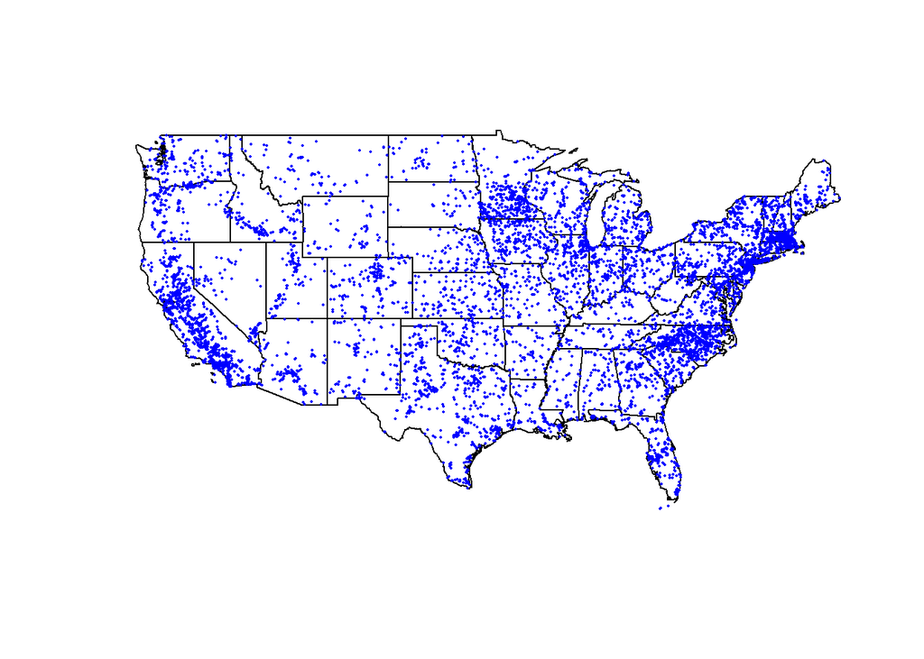

Mapping all power plants.

```r
load("data/maps/usa49reg.RData")
plot(usa49reg)
points(elc_pp$Longitude, elc_pp$Latitude, pch = 16, col = "blue", cex = .3)
```

```r
save(elc_pp, file = file.path(eiadir, "elc_pp.RData"))
```

```r
# continue..
elc_gn <- cleanread_xls(file.path(eiadir, "eia8602017/3_1_Generator_Y2017.xlsx"),
                      sheet = "Operable",
                      range = "A2:BU21439")
col_type <- sapply(elc_gn, class)
unique(col_type)
elc_gn


elc_genfue <- cleanread_xls(file.path(eiadir, "f923_2017/EIA923_Schedules_2_3_4_5_M_12_2017_Final_Revision.xlsx"),
                      sheet = "Page 1 Generation and Fuel Data",
                      range = "A6:CS13385")
elc_genfue
names(elc_genfue)
col_type <- sapply(elc_genfue, class)
unique(col_type)

# Split annual and monthly data
month_cols <- grepl(paste(month.name, collapse = "|"), names(elc_genfue))
summary(month_cols)

elc_genfue_y <- elc_genfue[, !month_cols]
dim(elc_genfue_y)

jj <- grepl("(Plant.id)|(YEAR)", names(elc_genfue), ignore.case = T)
elc_genfue_m <- bind_cols(elc_genfue[, which(jj)], elc_genfue[, month_cols])
dim(elc_genfue_m)

# reshape monthly data
aa <- gather(elc_genfue_m, key = "key", value = "value", -`Plant Id`, -YEAR)
aa$variable <- str_extract(aa$key, "^[a-zA-Z0-9_]+")
unique(aa$variable)
aa$month <- str_extract(aa$key, "[a-zA-Z0-9_]+$")
unique(aa$month)

elc_genfue_m <- select(aa, `Plant Id`, YEAR, month, variable, value)

elc_genfue <- left_join(elc_genfue_m, select(elc_genfue_y, -starts_with("Reserved")))

clean_names <- function(x) {
  nx <- names(x) %>%
    str_replace_all("\r\n", "_") %>%
    str_replace_all("\r", "_") %>%
    str_replace_all("\n", "_") %>%
    str_replace_all(" ", "_") %>%
    str_replace_all("__", "_")
  names(x) <- nx
  x
}

elc_genfue <- clean_names(elc_genfue)
names(elc_genfue)
```

### Processing plant-level data

```r
# Fuels
elc_genfue_y <- clean_names(elc_genfue_y)
names(elc_genfue_y)

unique(elc_genfue_y$Reported_Fuel_Type_Code)
unique(elc_genfue_y$AER_Fuel_Type_Code)

unique(elc_gn$Technology)
elc_gn <- clean_names(elc_gn)
names(elc_gn)

aa <- elc_gn %>% group_by(Technology, State) %>%
        summarise(cap = sum(`Nameplate_Capacity_(MW)`))

summary(aa)
sum(aa$cap)/1e3

(unique(aa$Technology))
```

# tbc

…